# A05 Answers

Olivia Martin

2022-10-11

**Instructions.** Change the author name on line 3 to be your name. Insert all requested answers. Upload in Moodle this file and a knitted file (html, doc, or pdf).

### Exercise 1 (25 points)

Consider the following histogram. Units are important!

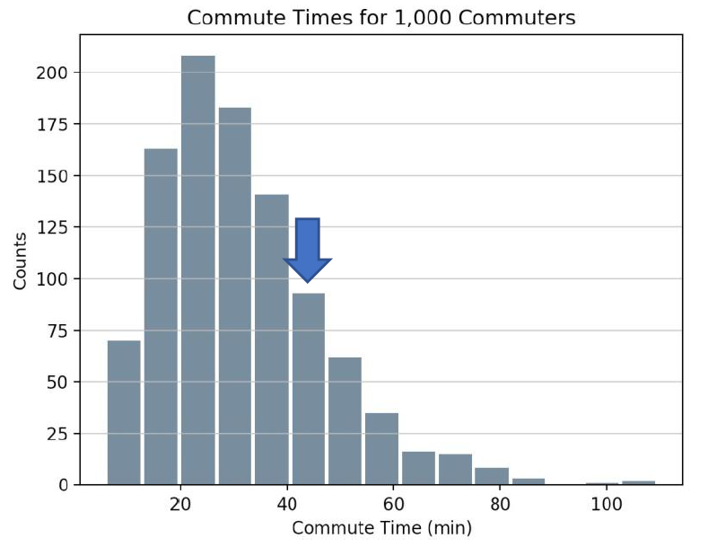

a. Describe the information provided by the bar that has an arrow pointing down at it in the histogram.

About 90 of the 1,000 commuters reported a commute time between 40 and roughly 47 minutes.

2. Estimate the median. Explain how you came up with your estimate.

I’d put the median around 26 minutes because bars to the left of that divide sum up to about 500.

4. Estimate the standard deviation. Explain how you came up with your estimate.

About 20 minutes, since nearly all of the data are within 60 minutes of the mean.

### Exercise 2 (20 points).

Choose a geographic location (e.g., Goshen Indiana) and consider the 365 daily high temperatures during 2022 in the chosen geographic location.

1. Estimate the mean and standard deviation.

   In Hyattsville, Maryland, the mean high temperature for 2021 (given that 2022 isn’t over yet) was probably about 65 degrees, and I think almost all of the temperatures would fit within 20 degrees of that, making the standard deviation about 7 degrees.
2. Sketch a density plot. Make sure you use appropriate scales and labels. For this part, you may hand in a hand drawing on paper or you could use a drawing program to create an image file that could be inserted here in the same way I inserted the image file in Exercise 1.

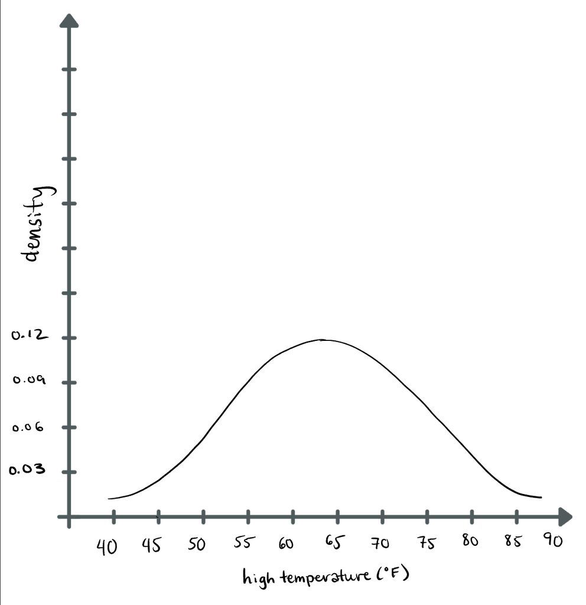

### Exercise 3 (50 points).

Consider the `Utilities` data set (part of the `mosaicData` package) as the data from a sample of a population.

1. Obtain the 7th case. Describe what this case represents.

   This case represents the billing period ending on June 24, 2000 and presumably beginning on May 31st, 2000. During this billing period, the average temperature in the area was 66 degrees Fahrenheit. During this time the residence used 583 kwh of electricity and 23 ccf of gas, averaging to 0.9 therms per day. The gas bill was $25.55 and the electric bill was $59.75, making the total bill $85.30.
2. Obtain a bar chart of the number of cases for each day (thought of as a categorical variable). Make sure the axes labels are meaningful. Give a possible explanation for the distribution that you observe.

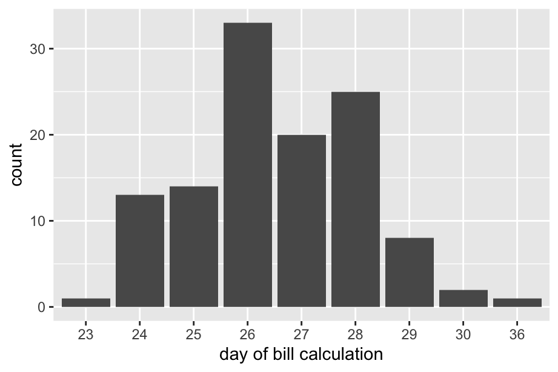

```r
Utilities %>% ggplot(aes(x = as_factor(day))) +
  geom_bar() +
  xlab('day of bill calculation')
```

I assume 36 is a typo. Aside from that, I would guess that the company usually intends to calculate its bills on the 26th of the month, but if that falls on a Saturday or Sunday, then it has to wait until the next Monday (hence the high volume of 27s and 28s), and if the 26th is a holiday, they might do the bill early or late (i.e., in December when the 26th is usually off for office workers, or if Thanksgiving is on the 26th they might do the bills on the 24th or 25th instead).

3. Obtain a density plot of electricity usage. Make sure the axes labels are meaningful. Give a possible explanation for the distribution that you observe.

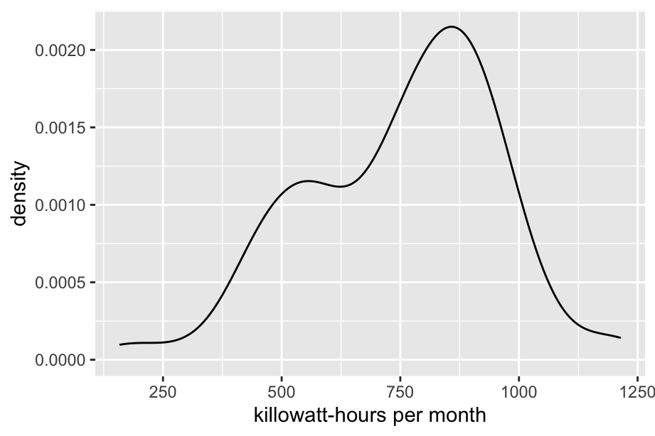

```r
Utilities %>% ggplot(aes(x = kwh)) +
  geom_density() +
  xlab('killowatt-hours per month')
```

According to a cursory google search, it takes more energy to heat a home than it does to cool one. In addition, the colder months are also the darkest, so it would presumably take more energy to light a home in the colder months. Thus, I would conjecture that the higher mode represents the colder months, with the cases to the right of 1000 perhaps corresponding to particularly cold winters. Likewise, the lower mode might represent the summer months when cooling is required fairly constantly. The cases to the left of 450 or so would probably include months with long vacations, as well as those bits of the year that the weather is perfect and the HVAC doesn’t need to be on. In DC, that’s mid-April to late May and mid-September to early October, but here I think it’s more like all of May and two weeks in September.

3. Obtain the mean, standard deviation, and 95% coverage interval for electricity usage. In addition to the computation, there should be a sentence that states your findings using appropriate units and precision.

```r
Utilities %>% summarise(mean = mean(kwh), sd = sd(kwh), lower = quantile(kwh, 0.025), upper = quantile(kwh, 0.975))
```

```
##       mean       sd lower  upper
## 1 750.9658 202.1078 385.1 1057.4
```

Over the period covered by the data, the residence used an average of 751.0 kwh per billing period, with a standard deviation of 202.1 kwh. In 95% of billing periods, the residence used between 385.1 and 1057.4 kwh of electricity.

3. Obtain a 95% confidence interval for the population mean electricity usage. In addition to the computation, there should be a sentence that states your findings using appropriate units and precision.

```r
rmean = function(n0) {
  Utilities %>%
    slice_sample(n = n0, replace = TRUE) %>%
    summarise(mean = mean(kwh))
}

x = tibble(mean = NULL)
for (i in 1:1000) {
  x = bind_rows(x, rmean(200))
}
x %>% summarise(quantile(mean, 0.025), quantile(mean, 0.975))
```

```
## # A tibble: 1 × 2
##   `quantile(mean, 0.025)` `quantile(mean, 0.975)`
##                     <dbl>                   <dbl>
## 1                    724.                    779.
```

### Exercise 4 (21 points).

Answer from *Statistical Modeling: End-of-Chapter Exercises* by Daniel Kaplan the following. I provide enough of each problem (Prob) or reading exercise (Read) so that it should be relatively easy to type your answers (text or code) in this file. I also provide some clarifications and hints.

**Read 5.2 (3 points).** What is resampling and bootstrapping?

Resampling is the process of sampling from a sample that was taken from the population. Instead of taking more samples from the population, you use the sample in lieu of the population and sample with replacement from that. Bootstrapping is the specific practice of resampling many times, then calculating a particular statistic for each resample and using them to find a confidence interval for the true value of that statistic for the whole population.

**Read 5.3 (3 points).** What is the difference between a “confidence interval” and a “coverage interval?”

Essentially, a coverage interval describes the spread of a sample, and a confidence interval describes the spread of a particular statistic across many instances of resampling. A 95% coverage interval tells you the minimum and maximum values for the center 95% of the data in the sample. A 95% confidence interval means that in the middle 95% of resamples, the mean or standard deviation or median or what have you was between the lower and upper values given in the interval. It gives you a range in which you can reasonably expect the true population value of your chosen statistic to lie.

**Prob 5.04 (2 points).** After a month’s hard work in the laboratory, you have measured a growth hormone from each of 40 plants and computed a confidence interval on the grand mean hormone concentration of 36 ± 8 ng/ml. Your advisor asks you to collect more samples until the margin of error is 4 ng/ml. Assuming the typical $1/\sqrt{n}$ relationship between the number of cases in the sample and the size of the margin of error, how many plants, including the 40 you have already processed, will you need to measure?

In order to halve the margin of error, you would need to increase the sample size fourfold. Your total sample size would have to be 160, including the 40 you have already measured.

**Prob 5.09 (2 points).** A student writes the following on a homework paper: “The 95% confidence interval is (9.6, 11.4). I’m very confident that this is accurate, because my sample mean of 10.5 lies within this interval.” Comment on the student’s reasoning.

The fact that the sample mean is within the confidence interval is less of a green flag and more the distinct lack of a red flag. If it wasn’t within the CI I’d assume I made a calculation error and check my math, but I wouldn’t ascribe any greater assurance to the accuracy than the 95% confidence we already have.

**Prob 5.10a (2 points).** Suppose the computer output is 0.03234232 ± 0.01837232. What should you report as the confidence interval?

**Note to self: rule of thumb is two significant digits for the margin of error, then match the number of decimal places for the mean.**

0.032 ± 0.018

**Prob 5.10b (2 points).** Suppose the computer output is 99.63742573 ± 1.48924367. What should you report as the confidence interval?

99.6 ± 1.5

**Prob 5.13 (3 points).** Why might it be reasonable to give a 50% coverage interval of the weight loss of individual clients, but not appropriate to give a 50% confidence interval on the mean weight loss.

The confidence interval doesn’t tell you anything about the spread of the actual data. It’s also odd because presumably they have weight loss data on all of their clients, so they can provide the population mean and wouldn’t necessarily need a confidence interval. A coverage interval would be far more appropriate because it describes the spread of the data itself.